# 3.3.2

R-korea -ML

20170928

## Extensions of the Linear Model

- additive
- linear

선형모델을 확장하는 classical approaches는 무엇일까?

### Removing the Additive Assumption

1. The linear models that formed the basis for this conclusion assumed that the effect on sales of increasing one advertising medium is independent of the amount spent on the other media.
2. 이러한 모델이 맞지 않는다면?
- $100,000 vs $50,000 + $50,000
- 판매량의 증가가 다를 수 있다!

> Synergy effect or Interaction effect

$$Y = \beta_0\ + \beta_1X_1 + \beta_2X_2 + \epsilon.$$

**모델을 확장하기 위해 interaction term을 포함시켜본다.**

$$Y = \beta_0\ + \beta_1X_1 + \beta_2X_2 + \beta_3X_1X_2 \epsilon\\
Y = \beta_0\ + (\beta_1 + \beta_3X_2)X_1 + \beta_2X_2 + \epsilon\\
=\beta_0 +\tilde(\beta_1)X_1 + \beta_2X_2 +\epsilon$$

- $\widetilde(\beta1)$ changes with $X_2$
- $X_2$를 변화 시키면 Y에 대한 $X_1$의 효과가 변할 것!

**For example**

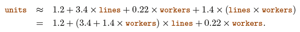

$$sales = \beta_0 + \beta_1XTV + \beta_2Xradio + \beta_3X(radioXTV)+\epsilon\\
=\beta_0+(\beta_1+\beta_3Xradio)XTV+\beta_2Xradio+\epsilon$$

- $\beta_3$ as the increase in the effectiveness of TV advertising for a one unit increase in radio advertising (or vice-versa).

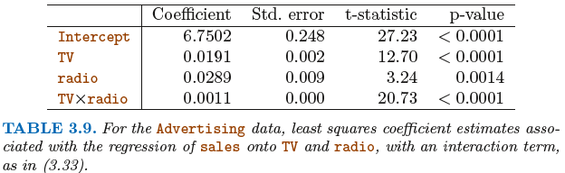

..

- 라디오 광고 지출이 $1,000 증가한다면?
- The hierarchical principle states that if we include an interaction in a model, we should also include the main effects,even if the p-values associated with their coefficients are not significant.
- $X_1$과 $X_2$의 상관관계를 고려

### Exampe of inter action effect

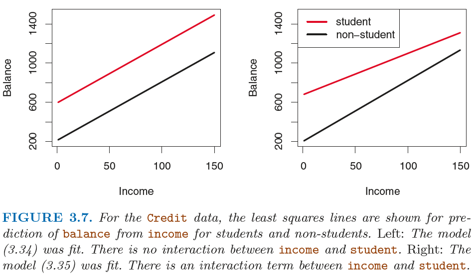

.

.

> In the absence of an interaction term

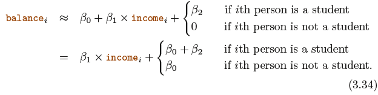

- Different intercepts, but same slope (left-had panel of upper picture)
- The fact that the lines are parallel means that the average effect on balance of a one-unit increase in income does not depend on whether or not the individual is a student(소득 변화 학생여부에 따르지 않고 credit card만 영향을 받는다.).

> Created by multiplying income with the dummy variable for student.

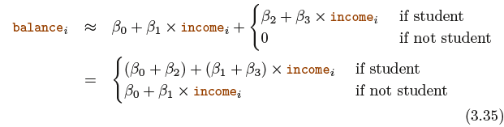

- Different intercepts and different slopes.
- This allows for the possibility that changes in income may affect the credit card balances of students and non-students differently.
- 소득 변화가 신용카드 대금에 미치는 영향이 학생 여부에 따라 다른지 살펴볼 수 있다.
- 소득 증가에 따른 카드 대금 증가가 학생이 더 낮다고 볼 수 있다.

### Non-linear Relationships

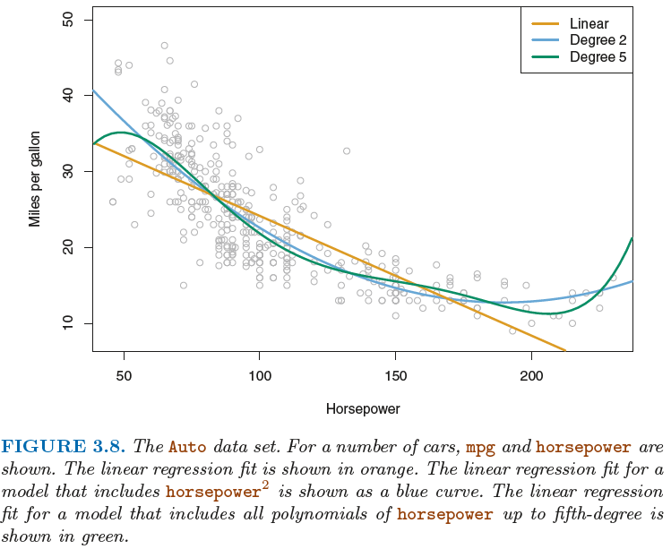

.

.

- orange line represents the linear regression fit.
- it seems clear that this relationship is in fact non-linear: the data suggest a curved relationship.
- seem to have a quadratic shape

$$mpg = \beta_0 + \beta_1Xhorsepower + \beta_2Xhorsepower^2 + \epsilon$$
___________________________________________________________________________________________________

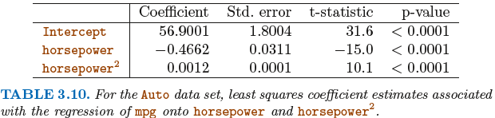

.

.

- If including horsepower2 led to such a big improvement in themodel, why not include horsepower3, horsepower4, or even horsepower5?
- -> it is unclear that including the additional terms really has led to a better fit to the data.
- We further explore this approach and other non-linear extensions of the linear model in Chapter 7.